# Lab: GORIC(A) Evidence Synthesis

## 1.2 Exercise 1b

- Do the same as in Exercise 1a for the data of Chandler (2015) - contained in the file C.txt. Btw, make sure to save the dataset in your working directory.
- The report by Chandler (2015) is also contained in the lab materials (“Ex2r Chandler_final.docx”).

**Click to show answers**

```r
### Replication of the JU study: C

C <- read.table("C.txt", header = TRUE)

C$g <- factor(C$g)
# this command tells R that 'g' is a factor and not a continuous variable like
# 'at'

## Inspect data head(C)

## Compute descriptives for each group descrip <- describeBy(C$z,C$g,mat=TRUE)
## print(descrip)


# lm object (of ANOVA model)
lm_fit_C <- lm(z ~ g - 1, data = C)

# Check names used in model
names(coef(lm_fit_C))
```

```
[1] "gph" "gpl" "grh" "grl"
```

```r
# Specify restrictions using those names


# Hypotheses Set
H1_C <- "grh > gph > grl > gpl"
H2_C <- "grh > gph = grl > gpl"
# Note, these are used as competing hypotheses.


# Calculate GORIC values and weights
set.seed(123)  # Set seed value
goric_C <- goric(lm_fit_C, hypotheses = list(H1_C = H1_C, H2_C = H2_C))
goric_C
```

```
restriktor (0.5-50): generalized order-restricted information criterion:

Results:
           model   loglik  penalty    goric  loglik.weights  penalty.weights  goric.weights
1           H1_C  -42.888    3.084   91.943           0.500            0.424          0.872
2           H2_C  -51.340    2.892  108.464           0.000            0.514          0.000
3  unconstrained  -42.888    5.000   95.775           0.500            0.062          0.128
```

```
---
Note: Hypotheses 'H1_C' and 'unconstrained' overlap (equal likelihood values). The GORIC(A) weights, are influenced solely by penalty value fluctuations, have an upper limit. If any overlap is most convincing (lowest GORIC(A) value in the full set), further evaluation against its complement is recom…
```

```r
# summary(goric_C) H1_C is not a weak hypothesis, since its support is stronger
# than for the unconstrained.  Since at least one of the competing hypotheses
# is not weak, one can compare their support.  It can be seen that H1_C
# receives the most support.  So, also in the replication study, we found
# support for 'H1'.
```

## 1.3 Exercise 1c

In Exercises 1a and 1b, you found the study-specific support for the central theory. In this exercise, you will aggregate this using the `evSyn()` function.

**Click to show answers**

```r
# Extract GORIC values from the studies
GORIC_studies <- list(goric_JU$result[, 4], goric_C$result[, 4])

# Evidence synthesis #
evSyn_anchor <- evSyn(GORIC_studies, hypo_names = goric_JU$result[, 1])

evSyn_anchor
```

```
restriktor (0.5-50): added Evidence Synthesis results:

Final GORICA weights:
        H1_JU          H2_JU  unconstrained
        0.979       1.01e-04          0.021
---

Ratio final GORICA weights:
               vs. H1_JU  vs. H2_JU  vs. unconstrained
H1_JU              1.000   9.68e+03             45.947
H2_JU           1.03e-04      1.000              0.005
unconstrained      0.022    210.614              1.000
```

```r
# summary(evSyn_anchor) plot(evSyn_anchor)
```

# 2 Exercise 2: Aggregating evidence from two studies

*Intro*  
- Imagine that you are in a group (unbeknownst to you, all the others in the group are actors) and that the atmosphere in the group is that criminal behavior is linked to having an African American background.  
- You publicly have to rate your attraction to a person in a video.  
- This is repeated using the same group of actors with you replaced by another person, that is, there are more participants in the experiment that have to rate the attraction to a person in a video.  
- There are three experimental conditions:

*Three conditions:*  
Condition 1: participants rate the attraction to a person that is ‘obedient’ and selects an African American person from a police line up of three.  
Condition 2: participants rate a moral rebel (a person not selecting the African American person) after executing a self-affirmation task intended to boost their self-confidence.  
Condition 3: participants rate a moral rebel after executing a bogus writing task.

*Two studies:*  
1st study: Explore & Obtain informative hypothesis(-es). *(1st study: Monin, Sawyer, and Marquez (2008))*  
Replicated study: Evaluate updated, informative hypothesis(-es). *(Replicated study: Holubar (2015).)*

*Goal studies:*  
Investigate the attraction to “moral rebels”, that is, persons that take an unpopular morally laudable stand.

*Hypotheses of interest*  
$H_1: \mu_1 = \mu_2 > \mu_3$ and  
$H_2: \mu_2 > \mu_1 > \mu_3$.

*Task*  
Do the same as in Exercise 1a, 1b, and 1c, but now using:  
- the data of Monin, Sawyer, and Marquez (2008) - contained in the file monin.txt  
- the data of, Holubar (2015) - contained in the file holubar.txt  
Btw, make sure to save the datasets in your working directory.

Alternatively, one can make use of the estimates and their covariance matrices of each of the studies. This is what we will use in the answers below.

**Click to show answers**

```r
# Study 1
monin <- read.table("monin.txt",header=TRUE)
monin$group <- factor(monin$group)       # this command tells R that group is a factor and not a continuous variable like attract
fit.lm_monin <-  lm(attract ~ group-1, data=monin)
#
# Study 2
holubar <- read.table("holubar.txt",header=TRUE)
holubar$gr <- factor(holubar$gr)       # this command tells R that gr is a factor and not a continuous variable like at
# lm object (of ANOVA model)
fit.lm_holubar <-  lm(at ~ gr-1, data=holubar)

### Input evidence synthesis: estimates and their covariance matrix
est_1 <- coef(fit.lm_monin)
est_2 <- coef(fit.lm_holubar)
# names(est_2) <- names(est_1)
Param_studies <- list(est_1, est_2)
Param_studies # To check the resulting list
```

```
[[1]]
group1 group2 group3
  1.88   2.54   0.02

[[2]]
 gr1  gr2  gr3
0.98 0.02 0.27
```

```r
#
vcov_est_1 <- vcov(fit.lm_monin)
vcov_est_2 <- vcov(fit.lm_holubar)
CovMx_studies <- list(vcov_est_1, vcov_est_2)

# Set of hypotheses for each study
# Note: in this case the same for each study, but different names are used.
# Either re-label estimate names as the same (as suggested above)
# or use study-specific estimates (as done next).
#
# names(est_1) # Specify restrictions using those names
H11 <- 'group1 = group2 > group3' #  equals 'group2 = group1 > group3'
H12 <- 'group2 > group1 > group3'
# names(est_2) # Specify restrictions using those names
H21 <- 'gr1 = gr2 > gr3'
H22 <- 'gr2 > gr1 > gr3'
#
#Hypo_studies <- list(H1 = list(H11, H21), H2 = list(H12, H22))
Hypo_studies <- list(S1 = list(H11, H12), S2 = list(H21, H22))
Safeguard <- "unconstrained"
#Hypo_studies <- list(H1 = list(H12, H22))
#Safeguard <- "complement"

# Evidence synthesis
evSyn_params <- evSyn(Param_studies, VCOV = CovMx_studies,
                      hypotheses = Hypo_studies,
                      #type = "added", # default
                      comparison = Safeguard)
#
#evSyn_params
summary(evSyn_params)
```

```
restriktor (0.5-50): added Evidence Synthesis results:

Study-specific results:

    GORICA weights:
               H1    H2 Unconstrained
    Study 1 0.387 0.469         0.143
    Study 2 0.308 0.227         0.465
    ---

    GORICA values:
               H1    H2 Unconstrained
    Study 1 4.492 4.108         6.478
    Study 2 5.770 6.377         4.942
    ---

    Log-likelihood weights:
               H1    H2 Unconstrained
    Study 1 0.231 0.384         0.384
    Study 2 0.114 0.114         0.772
    ---

    Log-likelihood values:
                H1     H2 Unconstrained
    Study 1 -0.746 -0.239        -0.239
    Study 2 -1.385 -1.385         0.529
    ---

    Penalty term values:
               H1    H2 Unconstrained
    Study 1 1.500 1.815         3.000
    Study 2 1.500 1.803         3.000
    ---

Cumulative results:

    GORICA weights:
                   H1    H2 Unconstrained
    Studies 1   0.387 0.469         0.143
    Studies 1-2 0.407 0.364         0.228
```

[output cut: 34 more lines]

```
Final ratios:

    GORICA weights:
                  vs. H1 vs. H2 vs. Unconstrained
    H1             1.000  1.118             1.784
    H2             0.894  1.000             1.596
    Unconstrained  0.560  0.627             1.000
    ---

    Log-likelihood weights:
                  vs. H1 vs. H2 vs. Unconstrained
    H1             1.000  0.602             0.089
    H2             1.660  1.000             0.147
    Unconstrained 11.257  6.782             1.000
    ---
```

```r
#plot(evSyn_params)
```

When inspecting the study-specific results, one can see that the studies do not prefer the same hypothesis (i.e., the result in the first study is not replicated by the second).

# 3 Exercise 3: Aggregating evidence from four heterogeneuous studies

*Example for synthesis if estimates are obtained already*

This example regards four trust studies described in Kuiper et al (2013). They all inspect the same central theories regarding (past) experience on trust in a different way, as a robustness check. The goal is to synthesize / aggregate / combine the evidence for the central theories of these four different studies.

All studies examine three central theories:  
- There is no effect of experience on trust ($H_{=}$).  
- There is a positive effect of experience on trust ($H_{+}$).  
- There is a negative effect of experience on trust ($H_{-}$).  
Note that the first one can be left out. Namely, when one find equal support for $H_{+}$ and $H_{-}$, this indicates support for $H_{=}$.

Notably, even though the study design differ, in all studies the (two) study-specific hypotheses that reflect the (two) central theories can be specific in the same way:  
$H_{+}: \beta_1 > 0$  
$H_{-}: \beta_1 < 0$

The $\beta_1$ estimates of the four studies and their standard errors (!) are:  
- $\beta_1$: 0.09, 0.14, 1.09, and 1.781.  
- s.e. of $\beta_1$: 0.029, 0.054, 0.093, and 0.179.

*Task*  
Perform evidence synthesis on these four heterogeneous studies.

**Click to show answers**

```r
#### 4 trust studies described in Kuiper et al (2013): H0, Hpos, Hneg ####
#In this example, we will use the data and hypotheses used in Kuiper et al. (2013).
#This article describes four diverse trust studies where each have a theory about the sign of the parameter of interest ($H_0$, $H_{pos}$ and $H_{neg}$).
#
#Please note the following:
#* You could also choose to discard the uninformative hypothesis $H_0$.
#* The GORICA only requires the structural parameters! Hence, we do not need to use all the parameters, but only the one of interest.

# In this example, all four studies have the same number of parameters of interest (namely 1; i.e., the hypotheses below address only one parameter).
est_1 <- c(beta1 = 0.09)
est_2 <- c(beta1 = 0.14)
est_3 <- c(beta1 = 1.09)
est_4 <- c(beta1 = 1.781)
Param_studies <- list(est_1, est_2, est_3, est_4)
Param_studies # To check the resulting list
```

```
[[1]]
beta1
 0.09

[[2]]
beta1
 0.14

[[3]]
beta1
 1.09

[[4]]
beta1
1.781
```

```r
#Furthermore, we need to specify the covariance matrix of the parameter estimates; for this matrix it is not necessary to specify the column names.
#Since there is only one parameter in the example, we only need the squared standard errors of the parameter estimate value - for each of the four studies.
vcov_est_1 <- matrix(c(0.029^2), nrow = 1)
vcov_est_2 <- matrix(c(0.054^2), nrow = 1)
vcov_est_3 <- matrix(c(0.093^2), nrow = 1)
vcov_est_4 <- matrix(c(0.179^2), nrow = 1)
CovMx_studies <- list(vcov_est_1, vcov_est_2, vcov_est_3, vcov_est_4)


## Evidence synthesis using the GORICA ##

# Set hypotheses #

# Now, we need to specify the hypotheses for all studies.
# In this example, all studies have the same set of hypotheses (consisting of three hypotheses)
H0 <- "beta1 == 0"
Hpos <- "beta1 > 0"
Hneg <- "beta1 < 0"
Hypo_studies <- list(H0, Hpos, Hneg)

# Then, we also need to set a safeguard-hypothesis, to prevent choosing a best hypothesis from a set of weak hypotheses.
# In this example, the whole space of theories is covered by the three hypotheses.
# Therefore, we do not need a safeguard-hypothesis here.
safeguard <- "none"


# Evidence synthesis #
# Before we can start with the evidence-synthesis, we need to set the type of evidence-synthesis:
# type = "added" (default) or type = "equal"
# In this case, we will use the default added-evidence approach.
evSyn_trust <- evSyn(object = Param_studies, VCOV = CovMx_studies,
                          hypotheses = Hypo_studies,
                          #type = "added", # Default
                          comparison = safeguard)

evSyn_trust
```

```
restriktor (0.5-50): added Evidence Synthesis results:

Final GORICA weights:
   H1     H2     H3
0.000  1.000  0.000
---

Ratio final GORICA weights:
      vs. H1  vs. H2    vs. H3
H1     1.000   0.000     7.389
H2  1.02e+54   1.000  7.54e+54
H3     0.135   0.000     1.000
```

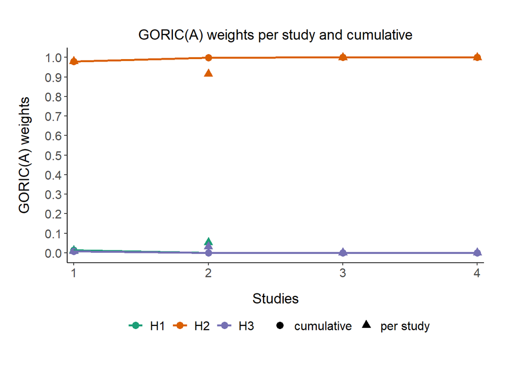

```r
plot(evSyn_trust)
```

## 3.1 Optional: Shiny web app

Do the same using the Shiny web app `GORIC(A) evidence synthesis’, available from https://www.uu.nl/staff/RMKuiper/Websites%20%2F%20Shiny%20apps.  
Note that the web app also links to a dropbox folder with example input files (including a tutorial).

# 4 Exercise 4: Aggregating evidence from studies using different subpopulations

Donwload and run the files in the subfolder `Example corona GGD' in`Examples evSyn’ on https://github.com/rebeccakuiper/Tutorials.

# 5 Exercise 5: Aggregating evidence from many heterogenous and homogenuous studies

Download and run the files in the subfolder `Example WtC' in`Examples evSyn’ on https://github.com/rebeccakuiper/Tutorials.

# 6 Exercise 6: Work on your own data (Optional)

In case you have multiple data sets or multiple primary studies investigating the same central theory, perform GORIC(A) evidence synthesis to quantify the overall support.